# RMarkdown: Just do it

Larissa Sayuri Futino C. dos Santos

11 de agosto de 2016

[figure not shown]

# Introdução

### Objetivos

A gente começa o Semestre 2/2016 com um grande exercício de metalinguagem. Vamos usar uma linguagem para descrever a si própria. Esse é um documento R Markdown com os objetivos de apresentar a linguagem, suas vantagens e usos e servir de modelo/base para futuras postagens do grupo.

### Conceitos e História

[figure not shown]

*Markdown* é uma linguagem simples para formatar sintaxe de arquivos a serem escritos em HTML, PDF e Word. Trata-se de uma *lightweight markup language (LML)*, ou seja, ela foi concebida para ser de fácil utilização a partir do uso de qualquer editor de texto genérico e de fácil leitura.

O primeiro pacote em R chamava-se *markdown* que tinha como objetivo principal gerar documentos em HTML. Para estatísticos, que usualmente precisam de citações, notas de rodapé e informações documentais como autor, data e título, o *markdown* não se mostrava uma ferramente realmente conveniente.

A necessidade de conversão para outros formatos também ficou muito recorrente e, nesses casos, recorria-se ao [Pandoc](http://pandoc.org/). *What?* Trata-se de um conversor universal de documentos com possibilidade de uso de:

- notas de rodapé;
- tabelas;
- listas de definição;
- aspas, sub-escritos e super-escritos;
- listas ordenadas e
- citações automáticas e bibliografias
- sintaxe LaTeX dentre muitos outros

Entretanto, o Pandoc todo poderoso exige o uso de muitos comandos de linha. O mesmo problema do knit, que é usado conjuntamente com o primeiro.

[figure not shown]

Logo, a equipe do [RStudio](https://blog.rstudio.org/2014/06/18/r-markdown-v2/) criou a segunda geração do R Markdown, que está sendo usada agora, com o objetivo de acrescentar uma interface amigável para customizar opções do Pandoc.

Em uma definição do R-bloggers:

[R-Markdown](http://rmarkdown.rstudio.com) *is a great way to create dynamic documents with embedded chunks of R code*.

# Vantagens

E realmente vale a pena usar o rmarkdown?

- O documento é
- auto-contido
- altamente reproduzível o que o torna facilmente compartilhável
- Você pode definir seus próprios *templates* e *outputs*
- O código R pode ser incluído ao relatório/documento de sorte que não o primeiro não se separa do segundo. A facilidade de um documento unificado evita re-trabalho.
- Especificamente para documentos HTML:
- O texto é escrito como um texto usual, ou seja, não há necessidade de conhecimento de linguagem HTML.
- O *output* inclui figuras, blocos de códigos e/ou resultados além do próprio texto. É um arquivo fácil de enviar por email ou de postar em um *website*.
- Um arquivo HTML facilita colaboração: É muito mais simples comentar uma análise quando o código, *output* e imagens estão disponíveis no mesmo arquivo.

# Mãos à obra!

Pressupondo que você é um usuário RStudio, ok? Se você não é… Instale! Vale a pena.

### Começando…

#### Criando um documento markdown

[figure not shown]

Passo 01: Clique em: File -> New File -> R Markdown.

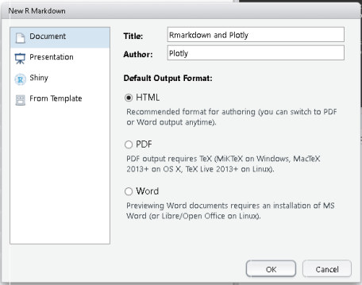

Passo 02: Na caixa de diálogo clique em Document e selecione o tipo HTML (o formato de postagens em blog que o grupo adotou).

[figure not shown]

Passo 03: Você deve se deparar com um documento similar a esse. Salve-o e repare que a extensão será .Rmd e é só começar!

#### Compilando

[figure not shown]

Passo 04: Para gerar o seu documento de interesse basta apertar o botão knit.

### *Chunks*, códigos, *outputs*, equações e gráficos

Quando o interesse é acrescentar partes do código R em meio ao documento utiliza-se o conceito de *chunk* de código (*code chunk*). Em uma tradução literal, são pedaços do código.

#### *Inline*

Se vc quer inserir um pedaço de código *inline* use apenas uma aspa simples para começar e terminar o *chunk*. Ao abrir o *chunk* comece pela letra ‘r’ e acrescente seu código. Botando os pingos nos i’s segue um *output* de código R: Mole, né? Tão fácil quanto 2 + 2 = 4.

E se fosse uma equação? É muito parecido com o Latex; entre dois cifrões ($) insere-se a expressão de interesse, por exemplo: $t^{'} = t \frac{1}{\sqrt{ 1 -\frac{v^{2}}{c^{2}} }}$

#### Entre linhas de texto

Basicão:

- Para abrir: três aspas invertidas seguidas da letra r entre chaves ({r})
- Para fechar: três aspas invertidas

A seguir, o código em um *chunk* e seu respectivo resultado:

```r
## Um classico: (Repare bem! Eh assim que se comenta codigo em um chunk do rmarkdown!)
paste("Alô Mundo RMarkdown!")
```

```
## [1] "Alô Mundo RMarkdown!"
```

Um *chunk* pode contemplar tudo de um código R usual: Chamada de pacotes, bases de dados, declaração e uso de funções e objetos além de *outputs*.

Vamos fazer um pequeno script para exemplificar.

```r
rm(list = ls())
gc()

require(googleVis)
op <- options(gvis.plot.tag="chart")

## Criando a nossa base
id <- 1:20
classif <- c(rep( "GrandMaster", 15), "Master", "GrandMaster", "Master", "GrandMaster", "Master")
exp <- c(4, 3, 3, 5, 3, 3, 5, 2, 6, 5, 4, 2, 5, 5, 3, 3, 4, 2, 5, 3)
Ouro <- c(24, 22, 18, 9, 5, 13, 18, 10, 16, 8 , 6, 6, 23, 5, 5, 3, 5, 4, 9, 7)
Prata <- c(20, 7, 20, 23, 6, 10, 14, 6, 20, 13, 25, 7, 10, 6, 5, 0 , 24, 0, 8 , 13)
Bronze <- c(18, 0, 20, 13, 4, 5, 4, 1, 12, 3, 16, 1, 5, 2, 5, 6, 9, 0, 10, 10)
pont <- c(216.177, 212.096, 193.549, 135.847, 127.354, 127.013, 121.055, 119.520, 112.719, 106.700,
          105.547, 105.539, 104.601, 98.255, 97.703, 97.514, 97.309, 97.307, 90.787, 87.930)

basecompet <- data.frame(id, classif, exp, Ouro, Prata, Bronze, pont)
rm(id, classif, exp, Ouro, Prata, Bronze, pont)
```

```r
## Criando uma funcao
fGrafColEmpil <- function(BASE, XVAR, YVAR, TITULO){
  Grafico <- gvisColumnChart(BASE,
                             xvar = XVAR,
                             yvar = YVAR,
                             options = list(isStacked = TRUE,
                                            title = TITULO,
                                            vAxes = "[{viewWindowMode:'explicit',
                                          viewWindow:{min:0, max:70}}]",
                                          legend ="{position: 'bottom', textStyle:                                                                            {fontSize:12}}",
                                          width = '900px', height = '400px',
                                          colors = "['#FFD700', '#CDC5BF', '#DAA520']"))
  return(Grafico)
}
```

```r
## Chamando a funcao
graficoColEmpil <- fGrafColEmpil(BASE = basecompet,
                                 XVAR = "id",
                                 YVAR = colnames(basecompet)[-c(1, 2, 3, ncol(basecompet))],
                                 TITULO = "Distribuição do total de medalhas por competidor")


plot(graficoColEmpil)
```

[output not shown]

O controle de todos os argumentos de um *chunk* não é imediato, você provavelmente vai procurar a sintaxe específica para o seu problema enquanto estiver trabalhando no seu documento. A vantagem é que tudo é bem documentado como por exemplo o [RMarkdownReference](https://www.rstudio.com/wp-content/uploads/2015/03/rmarkdown-reference.pdf/).

Obviamente, introduzir uma equação do Latex também é possível com a vantagem de que a sintaxe é exatamente igual ao mesmo.

### Bibliografia e citações

Em se tratando de referências e citações, em geral pouca dor de cabeça é coisa rara. No RMarkdown existem boas referências e uma delas chama a atenção: [Bibliografia e Citações](http://rmarkdown.rstudio.com/authoring_bibliographies_and_citations.html/).

No diretório onde está o seu script RMarkdown, deixe um arquivo em extensão .bib com as referências do seu trabalho. Claro, há outras extensões… Mas é bom lembrar que há uma fonte fácil de referências em sintaxe .bib: o Google Scholar.

É importante notar que para ter uma seção de Referências adicionamos nas primeiras linhas do código essa informação com o respectivo nome do arquivo .bib.

Além disso, a princípio, a sequência de referências vai constar depois da última linha de código, a qual equivale propositalmente à seção de Referências.

E que, assim como no Latex, um ícone bibliográfico aparece exclusivamente quando ele é referenciado. No meu script .bib existem três referências e eu vou referenciar apenas uma delas para que conste nesse arquivo, como uma forma didática e explicativa como sempre sugerem os sábios Silva and Prates (2016).

# Mãos à Obra

[figure not shown]

Fazendo jus ao título desse documento: é preciso começar!

Sugestão de Exercício: Temos uma página no github que é um tipo de identidade e a nossa voz. Cada um de nós agrega um valor muito específico em um grupo constituído exclusivamente de capital humano.

Faça uma apresentação à sua maneira em um formato de postagem para blog (HTML). Inclua seus dados, preferências, linhas de pesquisa e, se quiser, adicione algo pessoal como uma foto, seus *hobbies* e citações. Se todos concordarem, essas apresentações estarão na nossa página do github, ampliando nossa visibilidade individualmente e trazendo mais conhecimento sobre nós mesmos!

# Trabalhos Futuros

Dominar especificidades e minúcias do uso do RMarkdown e de HTML.

Referências

Silva, Luís Gustavo Silva e, and Marcos Oliveira Prates. 2016. *SpGoogle: Visualizing Spatial Data with Google*. http://CRAN.R-project.org/package=spGoogle.